# Hmk3

Github: https://github.com/t-aozy/Hmk3-STAT506

## Problem 1

### a. Download file, merge data

After merge the two data sets, the sample size is 6980.

```r
library(foreign)
data_vix <- read.xport("D:/VIX_D.XPT")
data_demod <- read.xport("D:/DEMO_D.XPT")
```

```r
# merge data
data_merge <- merge(data_vix, data_demod, by = "SEQN")

# print sample size
cat("sample size after merge:", nrow(data_merge))
```

```
sample size after merge: 6980
```

### b. Proportion of respondents within 10-year age bracket

VIQ220 : Do you wear glasses or contact lenses for distance vision, such as when you watch television?

VIQ220 in the data frame is a suitable variable to calculate the proportion, however, there are 433 data missing and also some people choose “Don’t know(9)” when being asked the question. So I filter people answer “Don’t know” and missing data.

Also, there are 148 missing data in terms of variable Age, the youngest individual is 144 months, older than 10 years old, so when calculating proportion, there is no need to calculate 0-10 years old bracket.

```r
library(knitr)
summary(data_merge$RIDAGEMN)
```

```
   Min. 1st Qu.  Median    Mean 3rd Qu.    Max.    NA's
  144.0   218.0   385.0   447.7   643.0  1019.0     148
```

```r
# drop missing values
data_merge <- data_merge[data_merge$VIQ220!=9,]
data_merge <- data_merge[!(is.na(data_merge$VIQ220)==TRUE|
                          is.na(data_merge$RIDAGEMN)==TRUE),]


# apply function
#' Proportion calculte the proportion that VIQ220 = 1(people who wear glasses)
#' @param x  data from a certain age group
#' @return proportion of people wear glasses
proportion <- function(x){
  prop <- nrow(x[x$VIQ220 == 1,])/nrow(x)
  return(prop)
}

# split into age groups
data_merge$agegroup <- cut(data_merge$RIDAGEMN,
                           breaks = c(120, 240, 360, 480,
                                      600, 720, 840, 960, 1080),
                           labels = c("10-20", "20-30", "30-40",
                                      "40-50", "50-60", "60-70",
                                      "70-80", "80-90")
                           )
data_merge$agegroup <- as.character(data_merge$agegroup)

# use kable
kable(
      tapply(data_merge, data_merge$agegroup, proportion),
      col.names = c("Age Group", "Proportion"),
      align = c("c","c"),
      digits = 3
      )
```

| Age Group | Proportion |
| --- | --- |
| 10-20 | 0.321 |
| 20-30 | 0.326 |
| 30-40 | 0.363 |
| 40-50 | 0.369 |
| 50-60 | 0.548 |
| 60-70 | 0.628 |
| 70-80 | 0.665 |
| 80-90 | 0.667 |

### c. Fit models

```r
# clean data
#(1 yes, 2 No)->(0 yes, 1 No)
data_merge$VIQ220 <- data_merge$VIQ220-1
#turn race into factor
data_merge$RIDRETH1 <- as.factor(data_merge$RIDRETH1)
#turn gender into factor (1 male,2 female)->(0 male 1 female)
data_merge$RIAGENDR <- as.factor(data_merge$RIAGENDR-1)



model_1 <- glm(VIQ220~RIDAGEMN,
               data = data_merge,
               family = binomial(link = "logit"))

model_2 <- glm(VIQ220~RIDAGEMN+RIDRETH1+RIAGENDR,
              data = data_merge,
              family = binomial(link = "logit"))

model_3 <- glm(VIQ220~RIDAGEMN+RIDRETH1+RIAGENDR+INDFMPIR,
              data = data_merge,
              family = binomial(link = "logit"))
```

```r
library(DescTools)
library(dplyr)
# get model result
m3_res <- as.data.frame(cbind(ODDS = t(exp(coef(model_3))),
                    AIC =  AIC(model_3),
                    R2 = PseudoR2(model_3),
                    SAMPLE = df.residual(model_3)+8
                    ), row.names = "Model 3")

m2_res <- as.data.frame(cbind(ODDS = t(exp(coef(model_2))),
                    AIC =  AIC(model_2),
                    R2 = PseudoR2(model_2),
                    SAMPLE = df.residual(model_2)+7
                    ), row.names = "Model 2")

m1_res <- as.data.frame(
              cbind(ODDS = t(exp(coef(model_1))),
                    AIC =  AIC(model_1),
                    R2 = PseudoR2(model_1),
                    SAMPLE = df.residual(model_1)+2
                    ),
              row.names = "Model 1")

df <- as.data.frame(t(bind_rows(m1_res, bind_rows(m2_res, m3_res))))
rownames(df) <- c("Intercept(Odds)", "Age(Odds)", "AIC", "R2",
                    "Sample", "Race2(Odds)", "Race3(Odds)", "Race4(Odds)",
                    "Race5(Odds)", "Gender1(Odds)", "Poverty(Odds)")

kable(
      df,
      align = c("ccc"),
      digits = 3
      )
```

|  | Model 1 | Model 2 | Model 3 |
| --- | --- | --- | --- |
| Intercept(Odds) | 3.589 | 6.498 | 7.771 |
| Age(Odds) | 0.998 | 0.998 | 0.998 |
| AIC | 8320.657 | 8130.957 | 7766.524 |
| R2 | 0.047 | 0.070 | 0.072 |
| Sample | 6422.000 | 6422.000 | 6136.000 |
| Race2(Odds) | NA | 0.852 | 0.887 |
| Race3(Odds) | NA | 0.510 | 0.606 |
| Race4(Odds) | NA | 0.761 | 0.803 |
| Race5(Odds) | NA | 0.512 | 0.576 |
| Gender1(Odds) | NA | 0.599 | 0.592 |
| Poverty(Odds) | NA | NA | 0.890 |

### d. Test whether the odds of men and women being wears of glasess differs.

```r
library(multcomp)
summary(glht(model_3, "RIAGENDR1 = 0"))
```

```
     Simultaneous Tests for General Linear Hypotheses

Fit: glm(formula = VIQ220 ~ RIDAGEMN + RIDRETH1 + RIAGENDR + INDFMPIR,
    family = binomial(link = "logit"), data = data_merge)

Linear Hypotheses:
               Estimate Std. Error z value Pr(>|z|)
RIAGENDR1 == 0 -0.52363    0.05485  -9.546   <2e-16 ***
---
Signif. codes:  0 '***' 0.001 '**' 0.01 '*' 0.05 '.' 0.1 ' ' 1
(Adjusted p values reported -- single-step method)
```

```r
# count people in each group
n1 <- nrow(data_merge[data_merge$RIAGENDR==0,]) #count male
p1 <- nrow(data_merge[data_merge$RIAGENDR==0 & data_merge$VIQ220==1,]) # male with glasses

n2 <- nrow(data_merge[data_merge$RIAGENDR==1,]) # female
p2 <- nrow(data_merge[data_merge$RIAGENDR==1 & data_merge$VIQ220==1,]) # female with glasses

prop.test( c(p1, p2), c(n1, n2),alternative = "two.side")
```

```
    2-sample test for equality of proportions with continuity correction

data:  c(p1, p2) out of c(n1, n2)
X-squared = 70.05, df = 1, p-value < 2.2e-16
alternative hypothesis: two.sided
95 percent confidence interval:
 0.07905646 0.12763584
sample estimates:
   prop 1    prop 2
0.6350922 0.5317460
```

## Problem 2

### a. What is the oldest movie?

The oldest movie was released in 2006, there are 1000 movies released in that year.

```r
library(DBI)
# import data
data_sakila <- dbConnect(RSQLite :: SQLite(), "D:/sakila_master.db")

dbGetQuery(data_sakila,"
SELECT COUNT(release_year),  MIN(release_year)
  FROM film
")
```

```
  COUNT(release_year) MIN(release_year)
1                1000              2006
```

### b. Least common genre

#### b.1 Regular R Operations

Music movie is the least common in the data, there are 51 movies in this genre.

```r
genre <-  dbGetQuery(data_sakila,"
SELECT *
  FROM film_category
")

genre_id <-  dbGetQuery(data_sakila,"
SELECT *
  FROM category
")

genre_merge <- merge(genre, genre_id, by = "category_id")


kable(
  table(genre_merge$name)[order(table(genre_merge$name))],
  col.names = c("Genre", "Freq")
)
```

| Genre | Freq |
| --- | --- |
| Music | 51 |
| Horror | 56 |
| Classics | 57 |
| Travel | 57 |
| Comedy | 58 |
| Children | 60 |
| Games | 61 |
| Sci-Fi | 61 |
| Drama | 62 |
| New | 63 |
| Action | 64 |
| Animation | 66 |
| Documentary | 68 |
| Family | 69 |
| Foreign | 73 |
| Sports | 74 |

#### b.2 SQL query

Music movie is the least common in the data, there are 51 movies in this genre.

```r
dbGetQuery(data_sakila,"
SELECT COUNT(f.category_id) as count,
       f.category_id  as id,
       c.name as name
  FROM film_category as f
      LEFT JOIN
      (SELECT *
         FROM category
      ) as c ON c.category_id = f.category_id
  GROUP BY f.category_id
  ORDER BY count
")
```

```
   count id        name
1     51 12       Music
2     56 11      Horror
3     57  4    Classics
4     57 16      Travel
5     58  5      Comedy
6     60  3    Children
7     61 10       Games
8     61 14      Sci-Fi
9     62  7       Drama
10    63 13         New
11    64  1      Action
12    66  2   Animation
13    68  6 Documentary
14    69  8      Family
15    73  9     Foreign
16    74 15      Sports
```

### c. Identity country with 13 customers.

#### c.1 Regular R Operations

Argentina and Nigeria have exactly 13 customers.

```r
# import customer, address, city, contry data
customer <- dbGetQuery(data_sakila,"
SELECT *
  FROM customer
")
address <- dbGetQuery(data_sakila,"
SELECT *
  FROM address
")
city <- dbGetQuery(data_sakila,"
SELECT *
  FROM city
")
country <- dbGetQuery(data_sakila,"
SELECT *
  FROM country
")


# merge data
data_country_merge <-
  merge(
    merge(
          merge(customer, address, by = "address_id")
          ,city, by = "city_id"
          ),
    country, by = "country_id"
  )
# count
country_count <- as.data.frame(table(data_country_merge$country))
names(country_count) <- c("country", "customer")
country_count[country_count$customer == 13,]
```

```
     country customer
6  Argentina       13
68   Nigeria       13
```

#### c.2 SQL query

Argentina and Nigeria have exactly 13 customers.

```r
dbGetQuery(data_sakila,"
SELECT  c.address_id as address,
        COUNT(c.customer_id) as count_customer, country.country
    FROM customer as c

    LEFT JOIN(
      SELECT *
        FROM address
    ) AS a ON a.address_id = c.address_id
    LEFT JOIN(
      SELECT *
        FROM city
    )AS city ON city.city_id = a.city_id
    LEFT JOIN(
      SELECT *
        FROM country
    ) AS country on country.country_id = city.country_id

  GROUP BY country.country
  HAVING count_customer ==13

")
```

```
  address count_customer   country
1      28             13 Argentina
2      22             13   Nigeria
```

## Problem 3

### a. “.com” Email address

73.2% email addresses are hosted at a domain with TLD “.com”.

```r
data_us <- read.csv("D:/us-500/us-500.csv")
data_com <- data_us[grepl("\\.com$", data_us$email),]

cat("proportion:", nrow(data_com)/nrow(data_us))
```

```
proportion: 0.732
```

### b. At least one non alphanumeric character

24.8% email addresses have at least one none alphanumeric character in them.

```r
n_special <- length(data_us$email[grep("[^0-9a-zA-Z@\\.]", data_us$email)])
n_special/nrow(data_us)
```

```
[1] 0.248
```

### c. Top 5 common area code

TOP 5 common area code: 973 212 215 410 201

```r
#' sub extract the first 3 numbers
#' @param x phone number
#' @return first 3 numbers
subsub <- function(x){
  return(substr(x, 1, 3))
}


# extract area code
data_us$area_code <-  mapply(subsub, data_us$phone1)
df <- as.data.frame(table(data_us$area_code))
names(df) <- c("area_code", "Freq")


kable(
  head(df[order(df$Freq, decreasing = TRUE),])
)
```

|  | area_code | Freq |
| --- | --- | --- |
| 158 | 973 | 18 |
| 9 | 212 | 14 |
| 12 | 215 | 14 |
| 47 | 410 | 14 |
| 1 | 201 | 12 |
| 24 | 305 | 9 |

### d. Log of the apartment numbers for all addresses.

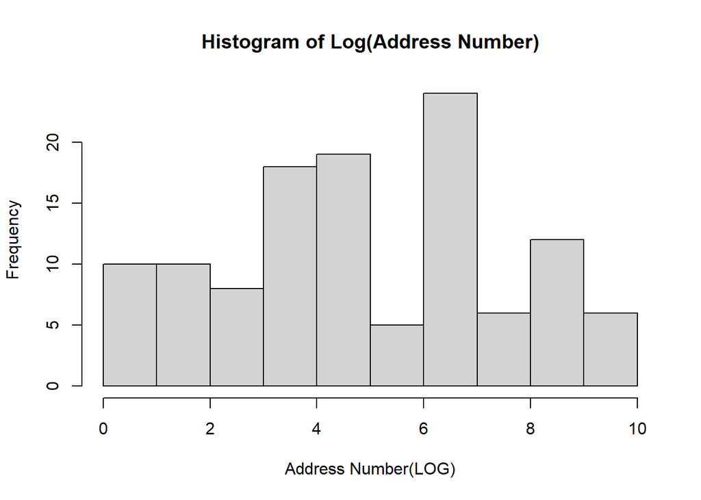

```r
add_num <- as.integer(regmatches(data_us$address,
                                 regexpr("[0-9]+$",
                                         data_us$address)))
hist(log(add_num),
     xlab = "Address Number(LOG)",
     main = "Histogram of Log(Address Number)"
     )
```

### e. Benford’s Law

According to Benford’s Law, leading digit is likely to be small, however, according to the barplot, we don’t see decreasing proportion from 1-9, so this data is not real data according to the rule.

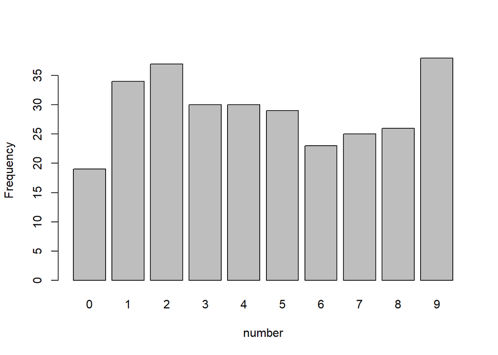

```r
string_all <- paste0(as.character(add_num), collapse = "")
split_all <- strsplit(string_all, "")

# Frequency of each number
barplot(table(split_all),
         xlab = "number",
         ylab = "Frequency")
```

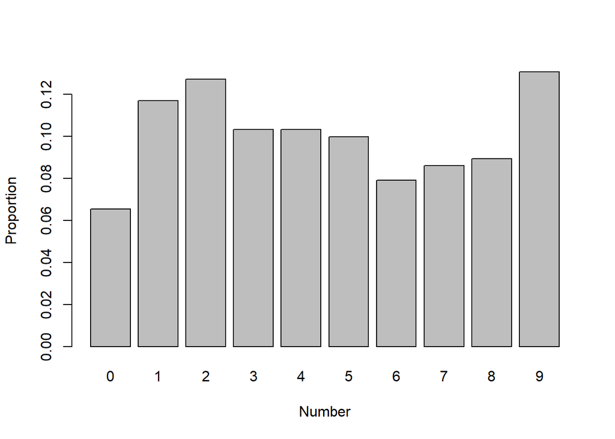

```r
# Proportion of each number
barplot(table(split_all)/length(split_all[[1]]),
         xlab = "Number", ylab = "Proportion")
```